# ABE 531 Watershed Delineation Module

Brady Nahkala

7/16/2020

# LIBRARY

The library loads new functions into R for you to utilize.

```r
library(raster)
library(here)
library(whitebox) # main geospatial package
library(mapview)
library(sf)
library(rayshader)
library(av)
```

# IMPORT DATA

This section imports the tif into an R object, lowers the resolution, and visualizes the DEM using plot().

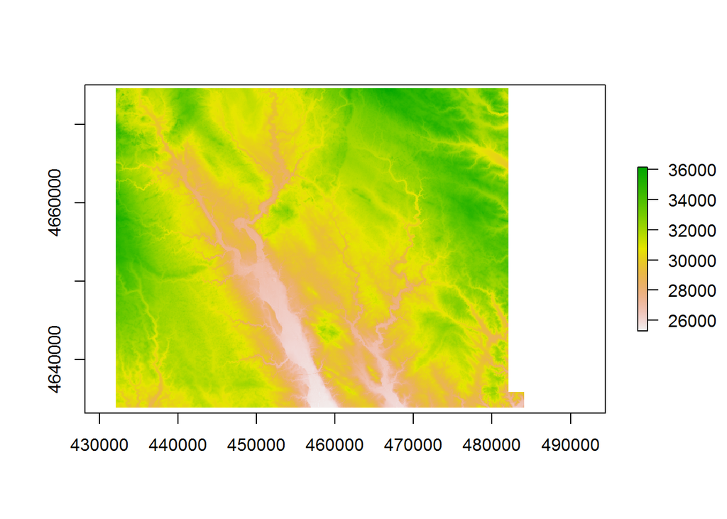

```r
dem <- raster(here("dem_story.tif"))

# TO REDUCE RASTER SIZE
course <- raster::aggregate(dem, 8)

# PROJECT THE DEM IN THE RIGHT MAPPING COORDINATE SYSTEM
# IA IS UTM ZONE 15 NORTH
dem15N <- projectRaster(course,crs = "+proj=utm +zone=15 +ellps=GRS80 +towgs84=0,0,0,0,0,0,0 +units=m +no_defs")
writeRaster(dem15N,here("data/dem15N.tif"), overwrite=TRUE)
plot(dem15N)
```

# FILL DEM

This section fills isolated depressions in the DEM so that there are not any isolated pools in the watershed. This step fills in many of the priarie potholes in the Des Moines Lobe, for example, which do not naturally drain to a stream.

```r
wbt_fill_depressions(here("data/dem15N.tif"),here("data/demFill.tif"))
```

```
## [1] "fill_depressions - Elapsed Time (excluding I/O): 0.241s"
```

```r
demFill <- raster(here("data/demFill.tif"))
```

# CREATE FLOW DIRECTION RASTER

This section analyzes the elevation dataset and decides which direction the water flows for each grid cell in the DEM.

```r
wbt_d8_pointer(here("data/demFill.tif"),here("data/flowDir.tif"))
```

```
## [1] "d8_pointer - Elapsed Time (excluding I/O): 0.82s"
```

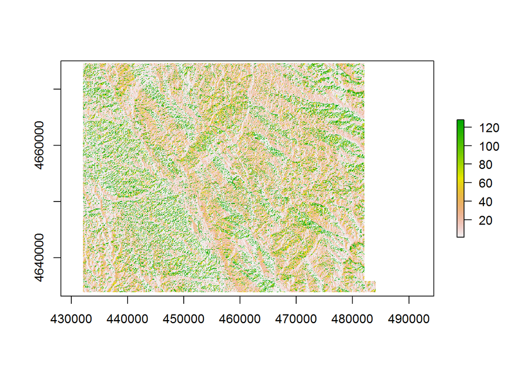

```r
flowDir <- raster(here("data/flowDir.tif"))
plot(flowDir)
```

# CREATE FLOW ACCUMULATION RASTER

This section processes the DEM by assessing how many upstream raster cells there are for each cell in the DEM.

```r
wbt_d8_flow_accumulation(here("data/demFill.tif"),here("data/flowAccumulation.tif"))
```

```
## [1] "d8_flow_accumulation - Elapsed Time (excluding I/O): 0.289s"
```

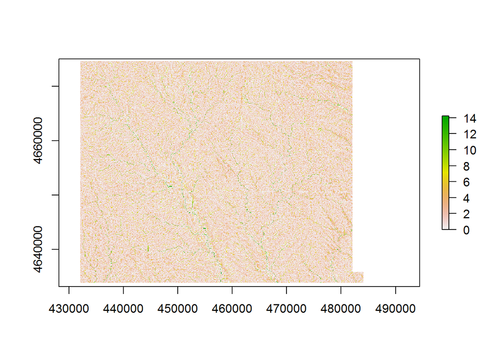

```r
flowAccum <- raster(here("data/flowAccumulation.tif"))
plot(log(flowAccum))
```

# CREATE AND SNAP POUR POINT

Here, the user inputs the location of the watershed outlet, and the functions snap that point to a stream network identified in the flow accumulation step.

```r
# Create the point
pts <- data.frame(x = -93.369500, y = 41.993048) # hickory grove (x = -93.369500, y=41.993048)
pointSF <- st_as_sf(pts, coords = c("x","y")
                    ,crs="+proj=longlat +datum=WGS84"
                    ) # tell R what the projection of the points are (latitude, longitude)

# Project the point into UTM 15N
pointSF15N <- st_transform(pointSF, crs = "+proj=utm +zone=15 +ellps=GRS80 +towgs84=0,0,0,0,0,0,0 +units=m +no_defs")
st_write(pointSF15N, here("data/pour15N.shp"))
```

```
## Writing layer `pour15N' to data source `C:/github/abe-watersheds/data/pour15N.shp' using driver `ESRI Shapefile'
## Writing 1 features with 0 fields and geometry type Point.
```

```r
# Snap the point and save it
wbt_snap_pour_points(here("data/pour15N.shp"),here("data/flowAccumulation.tif"),here("data/pourSnap"),snap_dist = 200, verbose_mode = TRUE)
```

```
## [1] "*****************************"      "* Welcome to SnapPourPoints *"
## [3] "*****************************"      "Reading data..."
## [5] "Progress: 9223372036854775808%"     "Saving data..."
## [7] "Output file written"                "Elapsed Time (excluding I/O): 0.0s"
```

```r
snap <- st_read(here("data/pourSnap.shp"))
```

```r
# mapview(snap)+
#   mapview(pointSF15N, col.regions = 'red') # view the point in an interactive map and compare the snapped point to the original
```

# DELINEATE WATERSHED

This section takes the steps prior and allows you to delineate the watershed for the specified point.

```r
# GENERATE WATERSHED
wbt_watershed(here("data/flowDir.tif"),here("data/pourSnap.shp"),here("data/watershed.tif"), verbose_mode = F)
```

```
## [1] "watershed - Elapsed Time (excluding I/O): 0.146s"
```

```r
# LOAD WATERSHED
watershed <- raster(here("data/watershed.tif"))
mapview(watershed)
```

[interactive chart not shown]

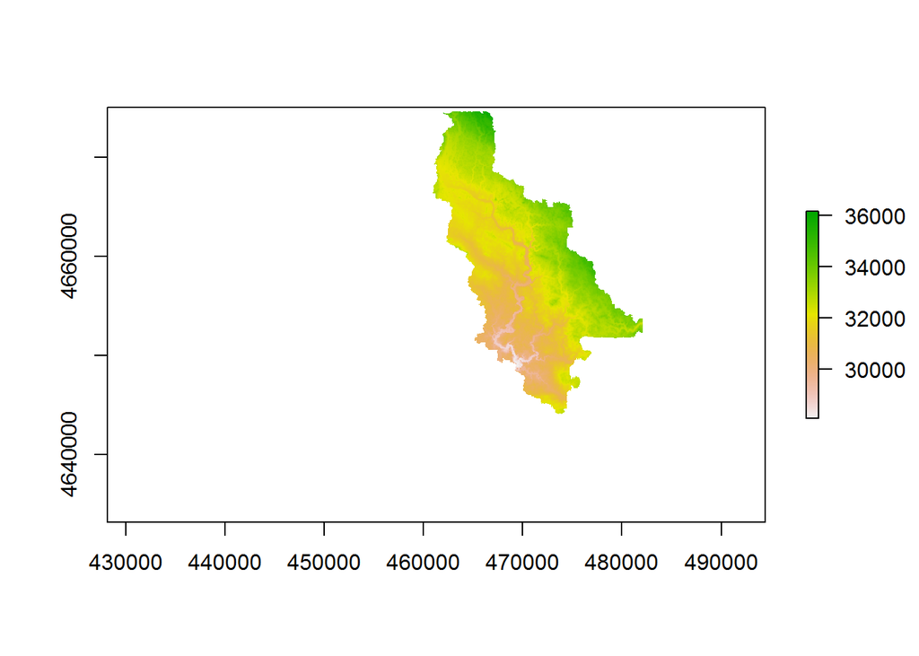

```r
# MASK DEM TO WATERSHED YOU CREATED
mask <- mask(dem15N,watershed)
plot(mask)
```

# 3D WATERSHED

This section is just for fun. The package ‘rayshader’ allows you to create a 3D animation of the watershed. Elevations exaggerated and low resolution for faster processing.

```r
 # If you need to reduce the resolution
course2 <- raster::aggregate(mask,8)

## Convert to matrix
elmat = raster_to_matrix(course2)

elmat %>%
  sphere_shade(texture = "imhof1") %>%
  add_water(detect_water(elmat), color = "imhof1") %>%
  add_shadow(ray_shade(elmat, zscale = 10), 0.5) %>%
  add_shadow(ambient_shade(elmat), 0) %>%
  plot_3d(elmat, zscale = 250, fov = 0, theta = 25, zoom = 0.35, phi = 25, windowsize = c(1000, 800))
render_snapshot()
```

[output not shown]

# Prairie Potholes

```r
demDif <- demFill-course
```

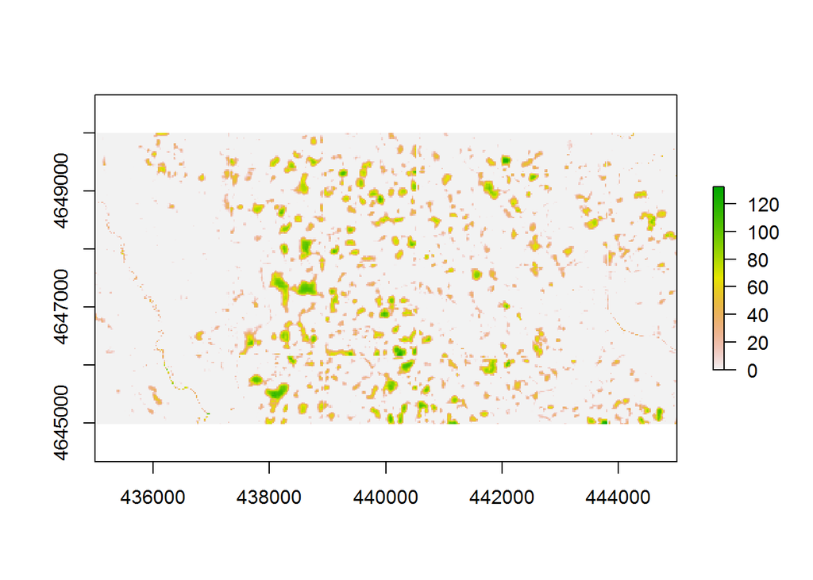

```r
plot(demDif
     , xlim=c(435000, 445000)
     , ylim=c(4645000, 4650000)
     )
```

```r
# mapview(demDif) # interactive map if you want to be fancy
```

# Unused Lat/Long Converter Function

```r
#Function
# LongLatToUTM<-function(x,y,zone){
#  xy <- data.frame(ID = 1:length(x), X = x, Y = y)
#  coordinates(xy) <- c("X", "Y")
#  proj4string(xy) <- CRS("+proj=longlat +datum=WGS84")  ## for example
#  res <- spTransform(xy, CRS(paste("+proj=utm +zone=",zone," ellps=WGS84",sep='')))
#  return(as.data.frame(res))
# }
```